# Motivations: R for Data Science

## Data Science Tools

## European Spreadsheet Risks Interest Group

Wait…this group even exists? Risks include “Systemic Financial Failure”???

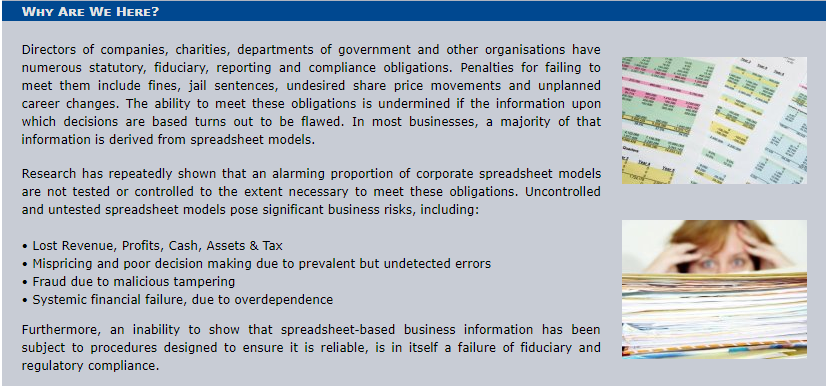

[Source: www.euspring.org](http://www.eusprig.org)

## They have a Horror Stories Page Too!

The Famous Rogoff-Reinhart excel error omits Denmark, Canada, Belgium, Austria, and Australia out of a key average, changing economic growth from positive to negative. The paper had been cited by conservative politicians to justify cuts to social programs. Colbert has a field day.

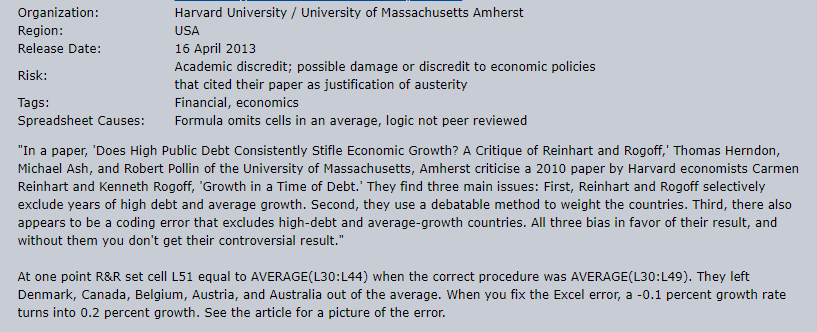

http://www.eusprig.org/horror-stories.htm

## Move beyond spreadsheets

*Although spreadsheet programs are used for small “scratchpad” applications, they are also used to develop many large applications. In recent years, we have learned a good deal about the errors that people make when they develop spreadsheets. In general, errors seem to occur in a few percent of all cells, meaning that for large spreadsheets, the issue is how many errors there are, not whether an error exists. These error rates, although troubling, are in line with those in programming and other human cognitive domains. In programming, we have learned to follow strict development disciplines to eliminate most errors.* - Raymond Panko

[Source: “What We Know About Spreadsheet Errors.”](http://panko.shidler.hawaii.edu/SSR/Mypapers/whatknow.htm)

## Burchworks Survey on Data Science Tools

Burch works is a decades old Chicago based recruiting firm specializing in analytics talent. The Survey of about 1000 is a “guesstimate”", reflecting their client base of traditional Chicago companies.

Results indicate `Python` the most popular, with `R` 2nd, and `SAS` 3rd and losing market share rapidly. Reflects a general shift to programming languages away from commercial analytics products.

**NOTE** Burchworks doesn’t appear to be using best practices in Data Science, Reproducible Research, or Survey methods, creating much ire among data professionals every year!

So don’t quote this as gospel!

[Source: Full ‘2019 Burtchworks Survey’ HERE](https://www.burtchworks.com/2019/08/21/2019-sas-r-or-python-survey-update-which-tool-do-data-scientists-analytics-pros-prefer/)

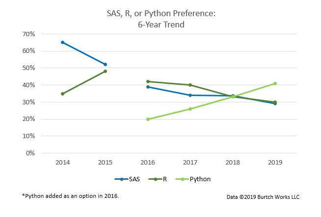

## IEEE, 2018 Top Programming languages

Amazingly, in the wider world of programming languages, the `R Statistical Programming language`, created by Data Scientists for **Data Scientists**, makes the “top 10” general programming language cut under the **Enterprise Catagory**, reflecting it’s growing use across scientific domains, business sectors, and Enterprises. It is very surprising for a specialized language to rank so high.

`Python`’s popularity is due to it’s high use in Web site development, DevOps, and as a general programming language. Use in web development and recent adaptation in **Data Science** has put it on top.

`C` and `C++` remains a stalwarts, and underpins `R`. Side note: R package developers use `C` and `C++` to speed up `R`.

[figure not shown]

[Source: IEEE 2018 top programming languages](https://spectrum.ieee.org/static/interactive-the-top-programming-languages-2018) [Source: IEEE 2018 Design, Methods, and Data](https://spectrum.ieee.org/static/ieee-top-programming-languages-2018-methods)

## Stackoverflow 2017 analysis of Languages

Stack Overflow graphs done with `R` helps us visualize that `R` is growing fast! [Source](https://stackoverflow.blog/2017/09/14/python-growing-quickly)

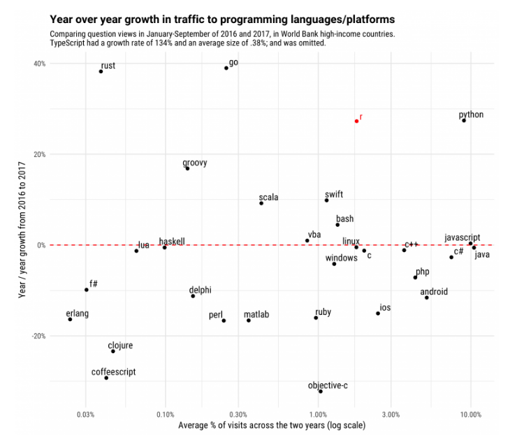

## Scripting languages: the core of Data Science

High Level languages like `R` interface with low level languages and Numerical computing libraries.

They are easier to program so analysts can fail fast on their research and start again. Most research ideas and science fail, so emphasis is placed on how fast one can churn them out.

Package ecosystem inherent to these languages allows scientists to contribute their work, with software they write. This has led to an explosion in the sharing of work across scientific disciplines.

## Python: From Web sites to Data Science

According to Stack Overflow:

*The fastest-growing use of `Python` is for data science, machine learning and academic research. This is particularly visible in the growth of the pandas package, which is the fastest-growing `Python`-related tag on the site.*

While Data Science with Python is really growing, its current popularity stems from its combined presence in web development, Sysadmin, and DevOps.

**Data Science:** `pandas`, `numpy`, `matplotlib`

**Web Developer:** `Javascript`, `django`, `HTML`

**Sysadmin/DevOps:** `Linux`, `Bash`, or `Windows`.

Source: Stack Overflow, Incredible growth of python

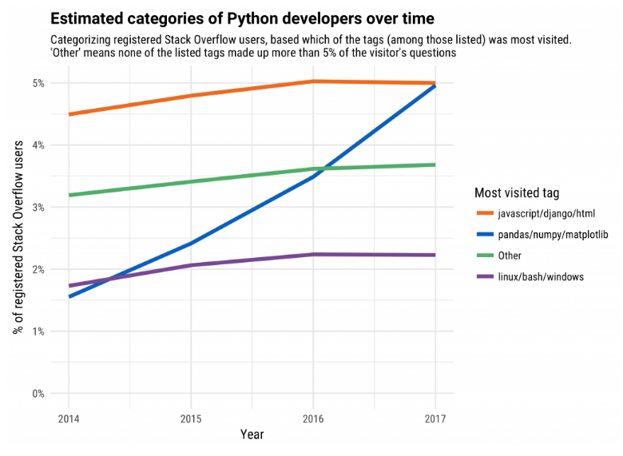

## R: created for Data Science, Growth by industry

*`R` is growing across industries, but visits are generally growing faster in industries where it was already more heavily visited.*

*`R` is most visited from universities, where it’s a common choice for academic research, especially in the social sciences and biology.*

*The industry with the second-highest share of `R` visitors, by a close margin, is healthcare. That probably won’t come as a surprise to biostatisticians, since `R` is the tool of choice for many statistical methods necessary for clinical studies and bioinformatics.* (R is mature. [It is used and OK’d by the FDA for drug trials](http://blog.revolutionanalytics.com/2012/06/fda-r-ok.html)

*One industry that doesn’t visit as much of `R`, relative to other technologies, is tech: software and web companies.*

[Source: Stack Overflow, impressive growth of R](https://stackoverflow.blog/2017/10/10/impressive-growth-r/)

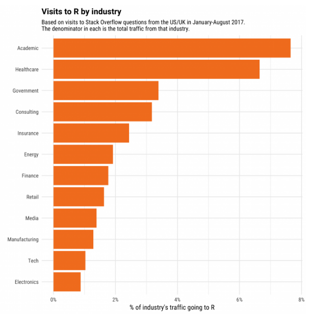

## Task Views in R

Years ago, I discovered `R` because I needed to use the most cutting edge, statistical modeling libraries available. With over 14862 packages available beyond base `R` as of this rendering, the community organizes noteworthy and mature approaches by research domain. They can ALL be installed with a few commands.

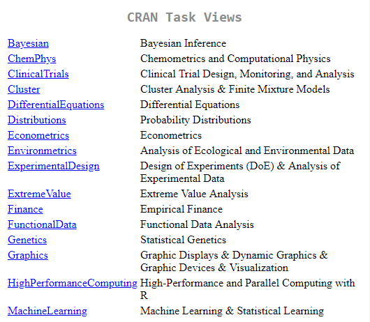

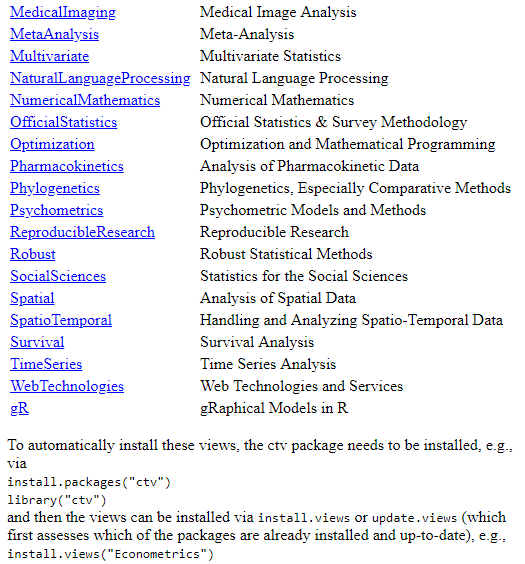

https://cran.r-project.org/web/views/

## (Some) R and Data Science History

## 1880: Statistician solves a Big Data problem

**1880** Since its inception in 1790, the U.S. census has expanded dramatically. It takes 8 years to process.

Herman Hollerith, *a Statistician of the 1880 census*, sets out to process it faster. Inspired by railway conductors, he creates punch cards to collect data. Inserted into a machine, the holes in each card allow an electrical circuit to complete, advancing a counting wheel for each topic and card.

**1890** The first census to use Hollerith’s Tabulating Machine is a success, completing in just 1 year.

**1896** Hollerith forms the “Tabulating Machine Company”, which later becomes “International Business Machines” better known today as “IBM”.

[figure not shown]

Sources: [Census.gov/history](https://www.census.gov/history/www/census_then_now/notable_alumni/herman_hollerith.html) and pg. 36 *The Innovators*, Walter Isaacson

## John Tukey, a Data Science pioneer

**1962** [*The Future of Data Analysis*](https://www.jstor.org/stable/2237638)

*I have come to feel that my central interest is in data analysis, which I take to include, among other things: procedures for analyzing data, techniques for interpreting the results of such procedures, ways of planning the gathering of data to make its analysis easier, more precise or more accurate, and all the machinery and results of (mathematical) statistics which apply to analyzing data.*

**1964** [*The technical tools of statistics*](http://ect.bell-labs.com/sl/tukey/memo/techtools.html)

*Today, software and hardware together provide far more powerful factories than most statisticians realize, factories that many of today’s most able young people find exciting and worth learning about on their own.*

**1939** Earns a Ph.D Mathematics, Princeton

**1947** Working with [Claude Shannon](https://en.wikipedia.org/wiki/Claude_Shannon) at **AT&T Bell Laboratories**, Tukey Invents the term “bit”

**1956** Sets up Princeton’s Statistical Techniques Research Group (STRG)

**1961** Promoted to Executive Director-Research Information Sciences at **AT&T Bell Laboratories**

**1965** 1st Chair of Princeton’s Statistics Department

**1965** Published influential paper on the Fast Fourier Transformation with J.W. Cooley, leading to the rapid development of digital signal processing

[Source: Memories of John W. Tukey](http://ect.bell-labs.com/sl/tukey/)

## 1977: John Tukey’s Exploratory Data Analysis

Spending over 30 years developing ground breaking methods still in use today, Tukey concludes visualization as one of the most important parts of data analysis.

**“Since the aim of exploratory data analysis is to learn what seems to be, it should be no surprise that pictures play a vital role in doing it well. There is nothing better for making you think of questions you had forgotten to ask (even mentally)”** - John Tukey

Tukey’s championing of EDA encouraged the development of statistical computing packages, especially `S` at Bell Labs. The `S` programming language inspired the systems `S-PLUS` and **`R`**. This family of statistical-computing environments featured vastly improved dynamic visualization capabilities, which allowed statisticians to identify outliers, trends and patterns in data that merited further study.

[figure not shown]

## Anscombe and his 1973 data quartet

Tukey and Anscombe often spoke of graphics as analysis. Anscombe’s plots illustrates. All 4 data sets return nearly identical linear regression coefficient estimates. However, viewing graphs of the data reveals each is quite different.

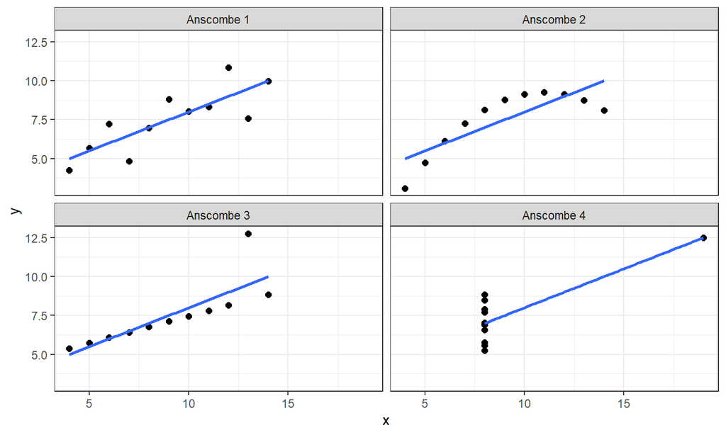

[Original Paper PDF: _Graphs in Statistical Analysis"](http://www.sjsu.edu/faculty/gerstman/StatPrimer/anscombe1973.pdf)

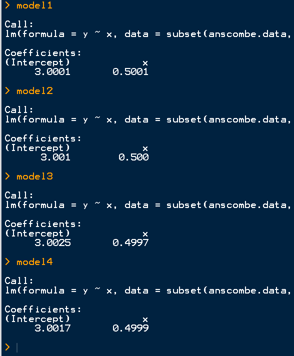

## Statistical/Machine Learning

Bridges statistics and computer science. Many early innovators among `S` & `R` communities at Stanford, Berkeley, and Bell Labs.

**1984** Classification and Regression Trees

**1994** Bagging Predictors, Leo Breiman

**1995** Random Decision Forests, Tin Kam Ho at **Bell**

**1999** `Random Forest` - *Random Features*, Breiman

**2000** `AdaBoost` Additive Logistic Regression: A Statistical View of Boosting. Jerome Friedman, Trevor Hastie, Rob Tibshirani.

**2001** [*The Two Cultures*](https://projecteuclid.org/euclid.ss/1009213726), Leo Breiman.

**2002** `randomForest` R package. Breiman’s Fortran ported to R by Andy Liaw and Matthew Wiener.

[Revolution Analytics: History of Ensemble Methods](http://blog.revolutionanalytics.com/2014/03/a-thumbnail-history-of-ensemble-methods.html)

[figure not shown]

## (Some) Data Analysis Software History

## Statistical Analsyis System (SAS)

**1966** The development of SAS began in 1966 after North Carolina State University rehired Anthony Barr to program his analysis of variance and regression software. The project was funded by the **National Institute of Health** to analyze agricultural data to improve crop yields

**1972** After issuing the first release of SAS, the project lost its funding. According to James Goodnight (the other project leader) this was because NIH only wanted to fund projects with medical applications. There was some disagreement on what the funding was used for.

**1976** Barr, Goodnight, Sall, and Helwig removed the project from North Carolina State and privatize it, incorporating it into SAS Institute, Inc.

[figure not shown]

**1980s - present** Private company grows to 3.2 Billion in annual sales and founders get rich!

However extremely large licensing costs and proprietary source code doesn’t allow leading researchers in academia or industry to adapt the software to current needs. As Data Analysis evolves into an interdisciplinary field, begins loses market share to free open source alternatives that have more flexibility to evolve quickly.

## 1977: Bell Labs, S, and R

*2000* John Chambers, core creator of the S Language

*The essence of what we took from him (Tukey) in thinking about S, for example, can be summarized in another of his famous one-liners, which goes roughly like this:*

*Better to have an approximate answer to the right question than a precise answer to the wrong question.*

*To me, this means that the data and the real goals of the analysis should suggest what questions need posing. A convenient or conventional summary is often not good enough. In this sense, I would say that enabling users to ask the “right” question (and to get a usable answer) is the most central design principle behind S, and behind nearly all the other research here on statistical software, before and since.*

## R (and S) for Humans, always the goal!

**1975** Richard Becker and John Chambers, both statisticians working on data analysis at Bell Labs and both computer scientists, were frustrated with having to interrupt their data analysis to do the required programming.

They wanted a more interactive process, where they could just type an expression at the command line and get back an immediate response, or better yet, a bar graph or other visual.

**1977: *Analalysis that was once difficult became easy in S*.**

**1991** `R`, based entirely on `S`, is created by Ross Ihaka and Robert Gentleman, borrowing all the hard-won lessons developed by the S community.

[Source: From S to R: 35 Years of Leadership in Statistical Computing](http://www.research.att.com/articles/featured_stories/2013_09/201309_SandR.html)

## A rich history of extending R

R succeeds today because it is very easy to extend.

If the driving force behind S was interactivity, for R it was extensibility. Partly this extensibility stems from S, which was designed to interface easily with outside elements (specifically with subroutine libraries). R retains this interfacing capability so it easily incorporates native code as well as objects, analysis, and visualizations created in other programs, giving R users options outside of R. And R is extensible also because it’s open source.

Objects created in other systems and then imported into R are accessed in the same way R objects are accessed. If one can write code in Java, C, C++, or other languages, mature bindings can use R to call the code directly, with little loss in speed or performance.

[Source: From S to R: 35 Years of Leadership in Statistical Computing](http://www.research.att.com/articles/featured_stories/2013_09/201309_SandR.html)

## Python: From WebDev to Data Science

General discussion

- Created in 1991 by Guido Von Rossum who wanted prettier `ABC` language.
- Mostly a webDev and SysAdmin language until the more recent release of `Pandas`, making the data.frame object available for the very first time. Author Wes McKinney works closely with senior developers in the `R` community who in the spirit of open source, show him the way.
- Python is also open source and has a large community of developers who help evolve it faster than any other data analysis software since `R`.
- Leap frogging ahead has left Python without many important graphical analysis tools and statistical/machine learning techniques that are still widely used in Data Analysis.
- A good language for learning general programming principals

## R and Data Science in Practice

## An R Projects workflow

**First Mile**: *Import* data and prepare for Analysis. Clean and format data. For example, make each variable a column, each observation is a row, etc. Alot of time is spent here.

**Data Analysis**: *Transform* data and create new variables with `log`, `exponents`, differencing, etc. *Visualizations* help spot outliers, remaining data problems, and reveal insights to test with *Models*. Predictive modeling frameworks like the [mlr (Machine Learning in R) package](https://mlr.mlr-org.com/) provide tools to quickly iterate over the entire process.

**Last Mile**: *Communicate* results with visualizations and good writing, exporting to static or interactive documents, webpages, apps, or presentation slides. Packages like [R Markdown](https://rmarkdown.rstudio.com/gallery.html) provides the scaffolding.

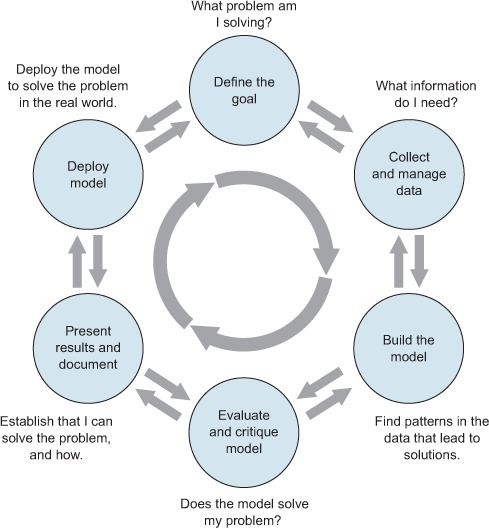

[Image Source: Practical Data Science with R](https://www.manning.com/books/practical-data-science-with-r-second-edition)

## What about ‘Big Data’ and R?

Szilard Pfafka: Physics PhD, chief (data) scientist @Epoch, and (visiting) UNCLA professor.

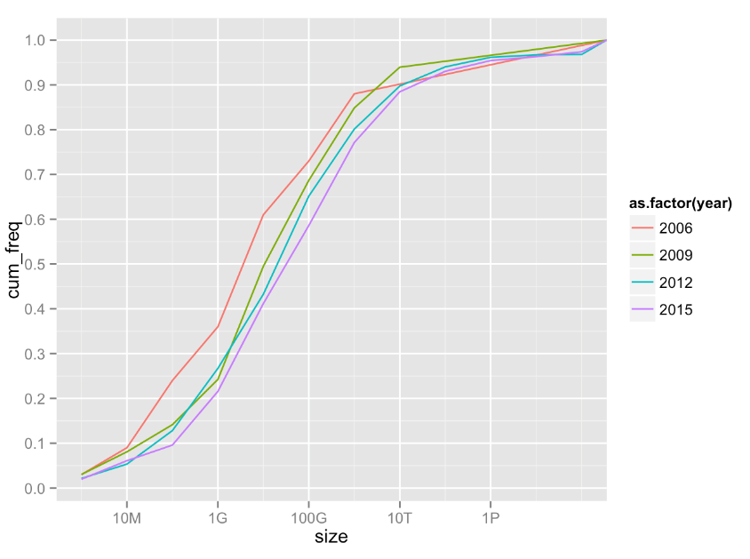

[Szilard Pfafka Source: dataset-sizes-kdnuggets](https://github.com/szilard/dataset-sizes-kdnuggets)

## What about ‘Big Data’ and R?

…and he points out that processing power is getting bigger!

R’s ability to compute on big data scales with processing power.

Processing power is increasing on the PC and cloud. Amazon AWS and Microsoft Azure provide access to lots of processing power for cheap.

This allows one to develop scripts locally on smaller sample data and then load scripts with bigger data into the cloud.

[Check out Microsoft Azure and R here](https://azure.microsoft.com/en-us/)

[2017-n1 meetup on useing AWS and R here](https://github.com/Chicago-R-User-Group/2017-n1-Meetup/blob/master/Hultman%2C%20Keith-Setting%20Up%20RStudio%20on%20AWS.pdf)

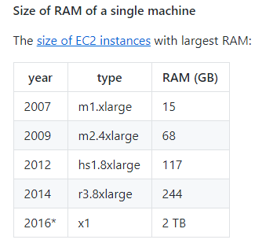

[Szilard Pfafka Source: dataset-sizes-kdnuggets](https://github.com/szilard/dataset-sizes-kdnuggets)

## How to learn more?

General discussion

- Continually study Statistics and Machine Learning, that is core of the work.
- [Practical Data Science with R](https://www.manning.com/books/practical-data-science-with-r-second-edition) is an excellent book
- [Datacamp.com](https://www.datacamp.com/) is excellent for learning how to do specific things and learn the language of R and Python.
- Signup for R, Python, and general Data [meetups](https://www.meetup.com/) and go! They are free, keep you current.